# India Health Care Center Analysis

# Frame

Given Health Care data explored in following manner.

1.Overall India Health Analysis 2.State wise presentation of the data etc.. fill as when required

# Acquire

data is scrapped from the https://data.gov.in/

Insight : It conatins the number of state-wise and district-wise availability of Sub-Centres, Primary Health Centres, Community Health Centres, Sub Divisional Hospitals and District hospitals In India till march 2016.

Following Abbreviations is used for the following

Primary Health Centers: PHC Community Health Centers :CHC Sub divisional hospitals : SDH District Hospital : DH SubCenters

```r
##### reading the data from .csv/xls files########################
df=read.csv("District-wise_Health_Centres_March_2016.csv",header=TRUE)
str(df)
```

```
'data.frame':   707 obs. of  8 variables:
 $ S.No.                                                       : Factor w/ 37 levels "1","10","11",..: 1 1 1 1 12 12 12 12 12 12 ...
 $ States.Union.Territory                                      : Factor w/ 37 levels "A & N Islands",..: 1 1 1 1 3 3 3 3 3 3 ...
 $ Name.of.the.District                                        : Factor w/ 661 levels "Aagar-Malwa",..: 437 442 574 614 25 127 278 176 220 341 ...
 $ Number.of.Sub.Centres....As.on.31st.March..2016.            : int  41 43 39 123 609 653 462 837 689 609 ...
 $ Number.of.PHCs....As.on.31st.March..2016.                   : int  4 8 10 22 80 94 70 119 82 81 ...
 $ Number.of.CHCs....As.on.31st.March..2016.                   : int  1 2 1 4 15 12 12 26 17 12 ...
 $ Number.of.Sub.Divisional.Hospital....As.on.31st.March..2016.: int  0 0 0 0 3 6 1 3 2 2 ...
 $ Number.of.District.Hospital....As.on.31st.March..2016.      : int  1 1 1 3 0 1 1 1 1 1 ...
```

Insigths 1. From the above table no missing value and NA Values 2. 0 value is present if corresponding health care doesnt present 3. All the columns contains the data as mentioned in the data overview 4. column name is too long and needs to be renamed for the further analysis

# Refine

Step1: ************************************************************* Rename the column name as it is very long ************************************************************

```r
newcolnames<-c('S.No.','states','District','#SubCentres','#PHC','#CHC','#SDH','#DH')
colnames(df)<-newcolnames
head(df)
```

|  | S.No. | states | District | #SubCentres | #PHC | #CHC | #SDH | #DH |
| --- | --- | --- | --- | --- | --- | --- | --- | --- |
| 1 | 1 | A & N Islands | Nicobar | 41 | 4 | 1 | 0 | 1 |
| 2 | 1 | A & N Islands | North & Middle Andaman | 43 | 8 | 2 | 0 | 1 |
| 3 | 1 | A & N Islands | South Andaman | 39 | 10 | 1 | 0 | 1 |
| 4 | 1 | A & N Islands | Total | 123 | 22 | 4 | 0 | 3 |
| 5 | 2 | Andhra Pradesh | Anantapur | 609 | 80 | 15 | 3 | 0 |
| 6 | 2 | Andhra Pradesh | Chittoor | 653 | 94 | 12 | 6 | 1 |

Insights:

From the above data , needs to change the data type of the first three column as it is factor

Step2: **************************************************************** Change the Data Type of the column ****************************************************************

```r
df$S.No.<- as.numeric(as.character(df$S.No.))
df$states<-as.character(df$states)
df$District<-as.character(df$District)
#check the kind of data it is storing
head(df,50)
```

|  | S.No. | states | District | #SubCentres | #PHC | #CHC | #SDH | #DH |
| --- | --- | --- | --- | --- | --- | --- | --- | --- |
| 1 | 1 | A & N Islands | Nicobar | 41 | 4 | 1 | 0 | 1 |
| 2 | 1 | A & N Islands | North & Middle Andaman | 43 | 8 | 2 | 0 | 1 |
| 3 | 1 | A & N Islands | South Andaman | 39 | 10 | 1 | 0 | 1 |
| 4 | 1 | A & N Islands | Total | 123 | 22 | 4 | 0 | 3 |
| 5 | 2 | Andhra Pradesh | Anantapur | 609 | 80 | 15 | 3 | 0 |
| 6 | 2 | Andhra Pradesh | Chittoor | 653 | 94 | 12 | 6 | 1 |
| 7 | 2 | Andhra Pradesh | Kadapa | 462 | 70 | 12 | 1 | 1 |
| 8 | 2 | Andhra Pradesh | East Godavari | 837 | 119 | 26 | 3 | 1 |
| 9 | 2 | Andhra Pradesh | Guntur | 689 | 82 | 17 | 2 | 1 |
| 10 | 2 | Andhra Pradesh | Krishna | 609 | 81 | 12 | 2 | 1 |

[output cut: 40 more lines]

```r
tail(df,50)
```

|  | S.No. | states | District | #SubCentres | #PHC | #CHC | #SDH | #DH |
| --- | --- | --- | --- | --- | --- | --- | --- | --- |
| 658 | 34 | Uttar Pradesh | Rampur | 211 | 32 | 5 | 0 | 2 |
| 659 | 34 | Uttar Pradesh | Saharanpur | 338 | 48 | 13 | 0 | 3 |
| 660 | 34 | Uttar Pradesh | Sambhal | 131 | 34 | 8 | 0 | 1 |
| 661 | 34 | Uttar Pradesh | Sant Ravidas Nagar | 155 | 21 | 6 | 0 | 2 |
| 662 | 34 | Uttar Pradesh | Santkabirnagar | 182 | 26 | 6 | 0 | 1 |
| 663 | 34 | Uttar Pradesh | Shahjahanpur | 310 | 51 | 13 | 0 | 2 |
| 664 | 34 | Uttar Pradesh | Shamli | 130 | 28 | 5 | 0 | 0 |
| 665 | 34 | Uttar Pradesh | Shrawasti | 133 | 17 | 6 | 0 | 1 |
| 666 | 34 | Uttar Pradesh | Siddharthanagar | 274 | 70 | 11 | 0 | 1 |
| 667 | 34 | Uttar Pradesh | Sitapur | 448 | 78 | 17 | 0 | 2 |

[output cut: 40 more lines]

Insights

1. Each states contain district-wise data as well as contain the total state wise data also
2. last row contains the all india total data

# Transform

# Explore

1. Visualise the All India data in the pie chart to give the overall idea of the different type of health centers

```r
library(dplyr)
library(ggplot2)
#retrive the last row of data frame which contain the all india health centers
tail(df,1,header=TRUE)
```

|  | S.No. | states | District | #SubCentres | #PHC | #CHC | #SDH | #DH |
| --- | --- | --- | --- | --- | --- | --- | --- | --- |
| 707 | NA | All India/ Total | Total | 155708 | 25387 | 5521 | 1065 | 773 |

```r
dc<- tail(df,1)
dat <- as.data.frame(t(dc))

#take only last  five rows of the dataframe
dat <-tail(dat,5)
dat
```

|  | 707 |
| --- | --- |
| #SubCentres | 155708 |
| #PHC | 25387 |
| #CHC | 5521 |
| #SDH | 1065 |
| #DH | 773 |

```r
dat$type<-c('#SubCenters','#PHC','#CHC','#SDH','#DH')
dat <-dat[,c(2,1)]
#assign the column names
colnames(dat)<-c("HealthCenterType","TotalCount")
#convert the column data type as integer from factor
dat$TotalCount=as.numeric(as.character(dat$TotalCount))
dat
```

|  | HealthCenterType | TotalCount |
| --- | --- | --- |
| #SubCentres | #SubCenters | 155708 |
| #PHC | #PHC | 25387 |
| #CHC | #CHC | 5521 |
| #SDH | #SDH | 1065 |
| #DH | #DH | 773 |

```r
#Pie Chart
dat$frac=dat$TotalCount/sum(dat$TotalCount)
dat
```

|  | HealthCenterType | TotalCount | frac |
| --- | --- | --- | --- |
| #SubCentres | #SubCenters | 155708 | 0.826238764 |
| #PHC | #PHC | 25387 | 0.134711919 |
| #CHC | #CHC | 5521 | 0.029296274 |
| #SDH | #SDH | 1065 | 0.005651246 |
| #DH | #DH | 773 | 0.004101797 |

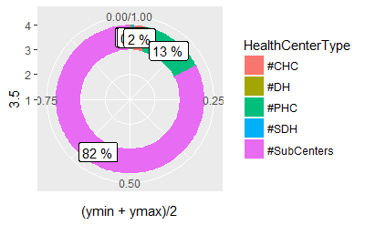

```r
dat = dat[order(dat$frac),]
dat$ymax = cumsum(dat$frac)
dat$ymin = c(0, head(dat$ymax, n=-1))
#p2 = ggplot(dat, aes(fill=HealthCenterType, ymax=ymax, ymin=ymin, xmax=4,min=3))+
 #    geom_rect(colour="grey30") +
  #   coord_polar(theta="y") +
   #  xlim(c(0, 4))
 #    theme_bw() +
 #    theme(panel.grid=element_blank()) +
 #    theme(axis.text=element_blank()) +
 #    theme(axis.ticks=element_blank()) +
  #   labs(title="Customized ring plot")
dchart=ggplot(dat) + geom_rect(aes(fill=HealthCenterType, ymax=ymax, ymin=ymin, xmax=4, xmin=3)) +
coord_polar(theta="y") + xlim(c(1, 4))
dchart+  geom_label(aes(label=paste(as.integer(frac*100),"%"),x=3.5,y=(ymin+ymax)/2),inherit.aes = TRUE, show.legend = FALSE)
```

```r
dat
```

|  | HealthCenterType | TotalCount | frac | ymax | ymin |
| --- | --- | --- | --- | --- | --- |
| #DH | #DH | 773 | 0.004101797 | 0.004101797 | 0.000000000 |
| #SDH | #SDH | 1065 | 0.005651246 | 0.009753043 | 0.004101797 |
| #CHC | #CHC | 5521 | 0.029296274 | 0.039049317 | 0.009753043 |
| #PHC | #PHC | 25387 | 0.134711919 | 0.173761236 | 0.039049317 |
| #SubCentres | #SubCenters | 155708 | 0.826238764 | 1.000000000 | 0.173761236 |

Step2: 1.find if there is relation between number size of the stat and the number of total health care center 2. More number of district depicts the size of the state. 3. Add one more column for number of district 4. One more column for the total number of health center in particular state

```r
library(dplyr)
#select only s.no states ,#SubCenters,#PHC,#CHC,#SDH,#DH and create a new data frame FOR statewise report
df_StateWiseData <-df[,c("states","#SubCentres","#PHC","#CHC","#SDH","#DH")]
#Add the new column district having value 1 to get the number of district
df_StateWiseData$District <- rep(1,nrow(df_StateWiseData))
df_StateWiseData <- df_StateWiseData %>%
                    group_by(states) %>%
                    summarise_each(funs(sum))




  df_StateWiseData <- df_StateWiseData %>%
                      filter(states!="All India/ Total")

  #reorder the column by changing the index
df_StateWiseData<-  df_StateWiseData[,c(1,7,2,3,4,5,6)]
head(df_StateWiseData,20)
```

| states | District | #SubCentres | #PHC | #CHC | #SDH | #DH |
| --- | --- | --- | --- | --- | --- | --- |
| A & N Islands | 4 | 246 | 44 | 8 | 0 | 6 |
| Andhra Pradesh | 14 | 15318 | 2150 | 386 | 62 | 16 |
| Arunachal Pradesh | 18 | 1176 | 286 | 126 | 0 | 36 |
| Assam | 28 | 9242 | 2028 | 302 | 28 | 50 |
| Bihar | 39 | 19458 | 3604 | 302 | 110 | 72 |
| Chandigarh | 1 | 17 | 3 | 2 | 1 | 1 |
| Chhattisgarh | 28 | 10372 | 1580 | 310 | 26 | 48 |
| Dadra & Nagar Haveli | 1 | 56 | 11 | 0 | 1 | 1 |
| Daman & Diu | 3 | 52 | 8 | 4 | 0 | 4 |
| Delhi | 12 | 52 | 10 | 0 | 20 | 94 |

[output cut: 10 more lines]

```r
df_StateWiseData$total_HealthCenter <- df_StateWiseData$`#SubCentres` +
                                       df_StateWiseData$`#PHC`   +
                                       df_StateWiseData$`#CHC` +
                                       df_StateWiseData$`#SDH` +
                                       df_StateWiseData$`#DH`
head(df_StateWiseData,20)
```

| states | District | #SubCentres | #PHC | #CHC | #SDH | #DH | total_HealthCenter |
| --- | --- | --- | --- | --- | --- | --- | --- |
| A & N Islands | 4 | 246 | 44 | 8 | 0 | 6 | 304 |
| Andhra Pradesh | 14 | 15318 | 2150 | 386 | 62 | 16 | 17932 |
| Arunachal Pradesh | 18 | 1176 | 286 | 126 | 0 | 36 | 1624 |
| Assam | 28 | 9242 | 2028 | 302 | 28 | 50 | 11650 |
| Bihar | 39 | 19458 | 3604 | 302 | 110 | 72 | 23546 |
| Chandigarh | 1 | 17 | 3 | 2 | 1 | 1 | 24 |
| Chhattisgarh | 28 | 10372 | 1580 | 310 | 26 | 48 | 12336 |
| Dadra & Nagar Haveli | 1 | 56 | 11 | 0 | 1 | 1 | 69 |
| Daman & Diu | 3 | 52 | 8 | 4 | 0 | 4 | 68 |
| Delhi | 12 | 52 | 10 | 0 | 20 | 94 | 176 |

[output cut: 10 more lines]

```r
NA
NA
```

Step3:Find the relation if number of health center is depending on the number of district 1. Draw the scatter plot

```r
library(ggplot2)
#data for regression  district and totalHealthCenter
df_reg <-df_StateWiseData[,c(2,8)]
#attach(df_StateWiseData)
#df_StateWiseData %>%
#                 plot(total_HealthCenter,District, main = "HealthCenter in India",xlab = #"Number of                     District",ylab = "total_HealthCenter",
#
df_reg
```

| District | total_HealthCenter |
| --- | --- |
| 4 | 304 |
| 14 | 17932 |
| 18 | 1624 |
| 28 | 11650 |
| 39 | 23546 |
| 1 | 24 |
| 28 | 12336 |
| 1 | 69 |
| 3 | 68 |
| 12 | 176 |

[output cut: 26 more lines]

```r
df_reg <-df_reg[order(District),]
df_reg
```

| District | total_HealthCenter |
| --- | --- |
| 1 | 24 |
| 1 | 69 |
| 1 | 24 |
| 3 | 68 |
| 3 | 482 |
| 4 | 304 |
| 5 | 170 |
| 5 | 354 |
| 9 | 2328 |
| 10 | 1062 |

[output cut: 26 more lines]

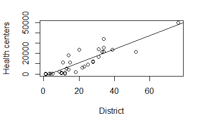

```r
#scatter diagram
plot(df_reg$District,df_reg$total_HealthCenter,xlab="District",ylab="Health centers")
abline(lm(df_reg$total_HealthCenter ~ df_reg$District))
```

Create the realtionship model between Number of district and health center opened –Assuming H0:b1=0 ,there is no relationship between the number of district and health care center H1:b1!=0 ,there is relatiom ship between the two variables

```r
relation <- lm(formula =total_HealthCenter ~ District,data=df_reg)
print(summary(relation))
```

```
Call:
lm(formula = total_HealthCenter ~ District, data = df_reg)

Residuals:
     Min       1Q   Median       3Q      Max
-10269.5  -4280.8   -530.3   1968.9  14236.8

Coefficients:
            Estimate Std. Error t value Pr(>|t|)
(Intercept) -2509.85    1487.93  -1.687    0.101
District      661.68      59.33  11.153 6.63e-13 ***
---
Signif. codes:  0 ‘***’ 0.001 ‘**’ 0.01 ‘*’ 0.05 ‘.’ 0.1 ‘ ’ 1

Residual standard error: 5565 on 34 degrees of freedom
Multiple R-squared:  0.7854,    Adjusted R-squared:  0.779
F-statistic: 124.4 on 1 and 34 DF,  p-value: 6.631e-13
```

Insights: Residuals are the difference between observed and the response value that is predicted from the model.

2. here from the result three significant star “***" ,means we reject the Null hypothesis that there is no relationship between size of the state and the Health center opened.

3.Intercept Estimation : when district is zero then average value of health center is -2509.85 4.slope estimated value :given one unit change in district expected change in healthcare is 661.65

5.Standard error for the slope is :59.33 which menas here variablity in coefficient value across the sample ,it is almost 11 times lesser than the coefficient value

6.probablityof coefficient is nearly zero and R2 is .78

7.From all the above point we reject the null hypothesis ,Number of health care opened is ~78 dependent on the size of state

predict the number of health care opened when the number of district in a state is 24 and 25

```r
new_df <-data.frame(District=c(24,25))
total_hc <- predict(relation,new_df)
print(total_hc)
```

```
       1        2
13370.45 14032.13
```

star plot for statewise Data

```r
require(grDevices)
data(df_StateWiseData)
```

[output not shown]

```
NAs introduced by coercionno non-missing arguments to min; returning Infno non-missing arguments to min; returning Infno non-missing arguments to max; returning -Inf
```

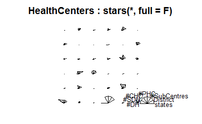

```r
palette(rainbow(12, s = 0.6, v = 0.75))
stars(df_StateWiseData[, 1:7], key.loc = c(14, 2),
      main = "HealthCenters : stars(*, full = F)", full = FALSE)
```

```
NAs introduced by coercionno non-missing arguments to min; returning Infno non-missing arguments to min; returning Infno non-missing arguments to max; returning -Inf
```

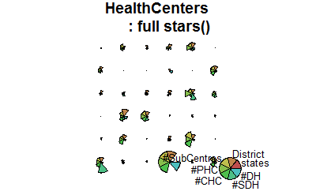

```r
stars(df_StateWiseData[, 1:7], key.loc = c(14, 1.5),col.segments = 1:nrow(df_StateWiseData)
      ,draw.segments = TRUE,
      main = "HealthCenters
      : full stars()", flip.labels = TRUE)
```